# Assignment A2 - Annotated Script

2149508

2022-07-11

```r
library(tidyverse) #set of packages for performing statistical transformations with data
library(lubridate) #for parsing date-time data
library(table1) #for publication ready statistical tables
library(knitr) #for report generation
library(gtsummary) #for summarizing tables for descriptive statistics
```

```r
library(rpart.plot) #machine learning algorithm for decision trees
library(rpart) #for drawing decision trees
library(caret) #for confusion matrix
library(survival) #for survival analysis
library(survminer)#for survival plots
```

### Let’s access the csv files and explore the data

```r
wales_data <- read.csv('Born in Wales Data June 2022.csv')
head(wales_data)
```

```
##   SYSTEM_ID Start.time Expected.date.of.delivery.of.your.baby
## 1         1 12/10/2020                             21/05/2021
## 2         2 13/10/2020                             25/11/2020
## 3         3 14/10/2020                             20/11/2020
## 4         4 15/10/2020                             07/01/2021
## 5         5 20/10/2020                             18/12/2020
## 6         6 21/10/2020                             07/12/2020
##   What.is.the.main.language.spoken.in.your.home. What.is.your.ethnic.group.
## 1                                        English                      White
## 2                                        English                      White
## 3                                        English                      White
## 4                                        English                      White
## 5                                        Swahili          Prefer not to say
## 6                                        English                      White
##         Nationality What.is.your.current.relationship.status..
## 1           British      Living with partner/civil partnership
## 2           British                                    Married
## 3           British      Living with partner/civil partnership
## 4           British                                    Married
## 5 Prefer not to say                                    Married
## 6           British                                    Dating
##   Would.you.consider.yourself.to.be.
## 1
## 2
## 3
## 4
## 5          Heterosexual or straight?
## 6          Heterosexual or straight?
##   Have.you.had.symptoms.that.are.associated.with.COVID19..fever..dry.cough..loss.of.taste.or.smell..fatigue..muscle.pain..
## 1
## 2
## 3
## 4
## 5                                                                                                                       No
## 6                                                                                                                       No
##   When.did.your.symptoms.start..approximately..
## 1
## 2
## 3
## 4                                     3/27/2020
```

[output cut: 358 more lines]

```
## 6             NA               NA                 NA                 NA
##   What.is.your.view.on.having.the.COVID.vaccination.in.pregnancy..have.you.or.would.you.have.the.COVID.vaccination.when.pregnant.and.why.
## 1
## 2
## 3
## 4
## 5
## 6
##   PLEASE.PRESS.SUBMIT.AT.THE.BOTTOM..Thank.you.very.much.for.completing.this.questionnaire..If.you.feel.there.is.something.that.we.should.have.asked.or.something.you.were.not.able.to.tell.us.please....
## 1
## 2
## 3
## 4
## 5
## 6
```

#Here we can see that the default for most of the variables is that they are character variables although a majority contain categorical data and some contain date-time data. The column names are too long and need to be adjusted. We don’t need the last column which asks the participants to submit the questionnaire, so we will exclude that. We will also not be needing the WIMD columns.

### Let’s exclude the less useful columns

```r
wales_data_2022 <- wales_data[, -c(68,69,70,71,73)]
```

### Let’s rename the columns to shorter names which are easier to read and understand

```r
column_names = c('Patient_ID', 'Start_date', 'EDD', 'Language', 'Ethnicity', 'Nationality', 'Marital_status', 'Gender', 'Covid_symptoms', 'Start_of_symptoms', 'Kind_of_symptoms', 'Treatment_taken', 'Test_taken', 'Low_mood_while_preg', 'Low_interest_in_activities', 'Depressed_or_hopeless', 'Trouble_sleep_or_too_much_sleep', 'Tiredness', 'Poor_appetite_or_overeating', 'Feel_bad_abt_self_or_failing_family', 'Trouble_concentrating', 'slow_movement_speech_fidget_restless', 'Thoughts_of_self_harm', 'Smoking', 'Alcohol', 'Nervous_or_anxious', 'Unable_to_stop_worry', 'Worrying_too_much', 'Trouble_relaxing', 'Restlessness', 'Annoyed_or_irritable', 'Fear_of_unknown', 'Physical_activity_at_work', 'Physical_activity_sports', 'Cycling_work_leisure', 'Walking_work_leisure', 'Housework_childcare', 'Gardening_DIY', 'Walking_pace', 'Wgt_b4_preg_kg', 'hgt_cm', 'Stress_in_preg', 'Relationship_issues', 'Legal_finance_issues', 'Victim_of_violence_crime_or_loved_one_is_victim', 'illness_of_loved_one', 'death_of_loved_one', 'is_event_covid_related', 'emotional_finance_support_at_this_time', 'scale_of_stress_at_this_time', 'satisfaction_with_healthcare_support_at_preg', 'effect_of_covid_on_birth_type', 'Type_of_maternity_care_received', 'Experience_with_midwife_feeling_abt_preg', 'mode_of_feeding_intent', 'Other_children', 'No_of_children', 'Age_of_children', 'Occupation', 'Education_level', 'Employment_status', 'Length_work_hrs', 'No_in_household', 'Household_income', 'Contact_with_others_no_touch', 'Touch_contact_with_others', 'Accuracy_of_contact_with_others', 'View_on_vaccine_while_preg')
colnames(wales_data_2022) <- column_names
```

### Let’s view the adjusted column names

```r
head(wales_data_2022)
```

```
##   Patient_ID Start_date        EDD Language         Ethnicity       Nationality
## 1          1 12/10/2020 21/05/2021  English             White           British
## 2          2 13/10/2020 25/11/2020  English             White           British
## 3          3 14/10/2020 20/11/2020  English             White           British
## 4          4 15/10/2020 07/01/2021  English             White           British
## 5          5 20/10/2020 18/12/2020  Swahili Prefer not to say Prefer not to say
## 6          6 21/10/2020 07/12/2020  English             White           British
##                          Marital_status                    Gender
## 1 Living with partner/civil partnership
## 2                               Married
## 3 Living with partner/civil partnership
## 4                               Married
## 5                               Married Heterosexual or straight?
## 6                               Dating  Heterosexual or straight?
##   Covid_symptoms Start_of_symptoms
## 1
## 2
## 3
## 4                        3/27/2020
## 5             No
## 6             No
##                                  Kind_of_symptoms
## 1
## 2
## 3
## 4 Cough;Muscle pain;Fatigue ;Loss of taste/smell;
## 5
## 6
##                                  Treatment_taken           Test_taken
## 1
## 2
## 3
## 4 Stayed at home, took over the counter medicine Yes, tested positive
## 5
## 6
##   Low_mood_while_preg Low_interest_in_activities   Depressed_or_hopeless
## 1                 Yes    More than half the days More than half the days
## 2                  No
## 3                 Yes               Several days            Several days
## 4                  No
```

[output cut: 169 more lines]

```
## 6                            2                         0
##                                  Accuracy_of_contact_with_others
## 1
## 2
## 3
## 4
## 5
## 6 Yes, I can remember very well who I had contact with yesterday
##   View_on_vaccine_while_preg
## 1
## 2
## 3
## 4
## 5
## 6
```

### Now let’s change all the columns that contain categorical data from character to factor variables.

```r
wales_data_2022$Language <- as.factor(wales_data_2022$Language)

wales_data_2022$Ethnicity <- as.factor(wales_data_2022$Ethnicity)

wales_data_2022$Nationality <- as.factor(wales_data_2022$Nationality)

wales_data_2022$Marital_status <- as.factor(wales_data_2022$Marital_status)

wales_data_2022$Gender <- as.factor(wales_data_2022$Gender)

wales_data_2022$Covid_symptoms <- as.factor(wales_data_2022$Covid_symptoms)

wales_data_2022$Treatment_taken <- as.factor(wales_data_2022$Treatment_taken)

wales_data_2022$Test_taken <- as.factor(wales_data_2022$Test_taken)

wales_data_2022$Low_mood_while_preg <- as.factor(wales_data_2022$Low_mood_while_preg)

wales_data_2022$Low_interest_in_activities <- as.factor(wales_data_2022$Low_interest_in_activities)

wales_data_2022$Depressed_or_hopeless <- as.factor(wales_data_2022$Depressed_or_hopeless)

wales_data_2022$Trouble_sleep_or_too_much_sleep <- as.factor(wales_data_2022$Trouble_sleep_or_too_much_sleep)

wales_data_2022$Tiredness <- as.factor(wales_data_2022$Tiredness)

wales_data_2022$Poor_appetite_or_overeating <- as.factor(wales_data_2022$Poor_appetite_or_overeating)

wales_data_2022$Feel_bad_abt_self_or_failing_family <- as.factor(wales_data_2022$Feel_bad_abt_self_or_failing_family)

wales_data_2022$Trouble_concentrating <- as.factor(wales_data_2022$Trouble_concentrating)

wales_data_2022$slow_movement_speech_fidget_restless <- as.factor(wales_data_2022$slow_movement_speech_fidget_restless)

wales_data_2022$Thoughts_of_self_harm <- as.factor(wales_data_2022$Thoughts_of_self_harm)

wales_data_2022$Smoking <- as.factor(wales_data_2022$Smoking)

wales_data_2022$Alcohol <- as.factor(wales_data_2022$Alcohol)

wales_data_2022$Nervous_or_anxious <- as.factor(wales_data_2022$Nervous_or_anxious)

wales_data_2022$Unable_to_stop_worry <- as.factor(wales_data_2022$Unable_to_stop_worry)

wales_data_2022$Worrying_too_much <- as.factor(wales_data_2022$Worrying_too_much)

wales_data_2022$Trouble_relaxing <- as.factor(wales_data_2022$Trouble_relaxing)

wales_data_2022$Restlessness <- as.factor(wales_data_2022$Restlessness)

wales_data_2022$Annoyed_or_irritable <- as.factor(wales_data_2022$Annoyed_or_irritable)

wales_data_2022$Fear_of_unknown <- as.factor(wales_data_2022$Fear_of_unknown)

wales_data_2022$Physical_activity_at_work <- as.factor(wales_data_2022$Physical_activity_at_work)

wales_data_2022$Physical_activity_sports <- as.factor(wales_data_2022$Physical_activity_sports)

wales_data_2022$Cycling_work_leisure <- as.factor(wales_data_2022$Cycling_work_leisure)

wales_data_2022$Walking_work_leisure <- as.factor(wales_data_2022$Walking_work_leisure)

wales_data_2022$Housework_childcare <- as.factor(wales_data_2022$Housework_childcare)

wales_data_2022$Gardening_DIY <- as.factor(wales_data_2022$Gardening_DIY)

wales_data_2022$Walking_pace <- as.factor(wales_data_2022$Walking_pace)

wales_data_2022$Stress_in_preg <- as.factor(wales_data_2022$Stress_in_preg)

wales_data_2022$Relationship_issues <- as.factor(wales_data_2022$Relationship_issues)

wales_data_2022$Legal_finance_issues <- as.factor(wales_data_2022$Legal_finance_issues)

wales_data_2022$Victim_of_violence_crime_or_loved_one_is_victim <- as.factor(wales_data_2022$Victim_of_violence_crime_or_loved_one_is_victim)

wales_data_2022$illness_of_loved_one <- as.factor(wales_data_2022$illness_of_loved_one)

wales_data_2022$death_of_loved_one <- as.factor(wales_data_2022$death_of_loved_one)

wales_data_2022$is_event_covid_related <- as.factor(wales_data_2022$is_event_covid_related)

wales_data_2022$emotional_finance_support_at_this_time <- as.factor(wales_data_2022$emotional_finance_support_at_this_time)

wales_data_2022$effect_of_covid_on_birth_type <- as.factor(wales_data_2022$effect_of_covid_on_birth_type)

wales_data_2022$Type_of_maternity_care_received <- as.factor(wales_data_2022$Type_of_maternity_care_received)

wales_data_2022$mode_of_feeding_intent <- as.factor(wales_data_2022$mode_of_feeding_intent)

wales_data_2022$Other_children <- as.factor(wales_data_2022$Other_children)

wales_data_2022$Education_level <- as.factor(wales_data_2022$Education_level)

wales_data_2022$Employment_status <- as.factor(wales_data_2022$Employment_status)

wales_data_2022$Length_work_hrs <- as.factor(wales_data_2022$Length_work_hrs)

wales_data_2022$Household_income <- as.factor(wales_data_2022$Household_income)

wales_data_2022$Accuracy_of_contact_with_others <- as.factor(wales_data_2022$Accuracy_of_contact_with_others)

wales_data_2022$View_on_vaccine_while_preg <- as.factor(wales_data_2022$View_on_vaccine_while_preg)

wales_data_2022$satisfaction_with_healthcare_support_at_preg <- as.factor(wales_data_2022$satisfaction_with_healthcare_support_at_preg)

wales_data_2022$scale_of_stress_at_this_time <- as.factor(wales_data_2022$scale_of_stress_at_this_time)
```

### Let’s see the adjusted variables

```r
str(wales_data_2022)
```

```
## 'data.frame':    753 obs. of  68 variables:
##  $ Patient_ID                                     : int  1 2 3 4 5 6 7 8 9 10 ...
##  $ Start_date                                     : chr  "12/10/2020" "13/10/2020" "14/10/2020" "15/10/2020" ...
##  $ EDD                                            : chr  "21/05/2021" "25/11/2020" "20/11/2020" "07/01/2021" ...
##  $ Language                                       : Factor w/ 14 levels "","Bilingual Wel/Eng",..: 4 4 4 4 12 4 4 4 14 4 ...
##  $ Ethnicity                                      : Factor w/ 6 levels "","Asian","Chinese",..: 6 6 6 6 5 6 6 6 6 6 ...
##  $ Nationality                                    : Factor w/ 14 levels "","American",..: 4 4 4 4 12 4 4 4 13 4 ...
##  $ Marital_status                                 : Factor w/ 11 levels "","Dating","Dating ",..: 6 7 6 7 7 3 7 6 7 7 ...
##  $ Gender                                         : Factor w/ 6 levels "","Bisexual?",..: 1 1 1 1 3 3 3 2 3 3 ...
##  $ Covid_symptoms                                 : Factor w/ 3 levels "","No","Yes": 1 1 1 1 2 2 2 3 2 2 ...
##  $ Start_of_symptoms                              : chr  "" "" "" "3/27/2020" ...
##  $ Kind_of_symptoms                               : chr  "" "" "" "Cough;Muscle pain;Fatigue ;Loss of taste/smell;" ...
##  $ Treatment_taken                                : Factor w/ 4 levels "","Stayed at home took, prescription medicine from GP",..: 1 1 1 4 1 1 1 4 1 1 ...
##  $ Test_taken                                     : Factor w/ 6 levels "","No, not given a test",..: 1 1 1 6 1 1 1 2 1 1 ...
##  $ Low_mood_while_preg                            : Factor w/ 3 levels "","No","Yes": 3 2 3 2 1 3 2 3 1 2 ...
```

[output cut: 54 more lines]

#Here we see that we can now easily access the different levels of the categorical variables. But some variables are showing up to 14 levels which is a lot. There might be duplicate levels.

### Let’s see all the levels of the categorical variables

```r
lapply(wales_data_2022, levels)
```

```
## $Patient_ID
## NULL
##
## $Start_date
## NULL
##
## $EDD
## NULL
##
## $Language
##  [1] ""                             "Bilingual Wel/Eng"
##  [3] "Bilingual Welsh and English " "English"
##  [5] "English and Welsh"            "Equal welsh/English"
##  [7] "Greek"                        "Italian"
##  [9] "Polish"                       "Portuguese "
```

[output cut: 695 more lines]

### Let’s group the levels

```r
wales_data_2022$Language <- recode(wales_data_2022$Language, 'Bilingual Welsh and English ' = 'English', 'English and Welsh' = 'English', 'Bilingual Wel/Eng' = 'English', 'Equal welsh/English' = 'English', 'Greek' = 'Other', 'Waray waray' = 'Other', 'Spanish ' = 'Other', 'Italian' = 'Other', 'Portuguese ' = 'Other', 'Polish' = 'Other', 'Swahili' = 'Other')

wales_data_2022$Ethnicity <- recode(wales_data_2022$Ethnicity, 'Chinese' = 'Asian', 'Prefer not to say' = 'Other')

wales_data_2022$Nationality <- recode(wales_data_2022$Nationality, 'American' = 'Other', 'Brazilian' = 'Other', 'Filipino' = 'Other', 'Greek' = 'European', 'Indian' = 'Other', 'Irish' = 'British', 'New Zealand' = 'Other', 'Prefer not to say' = 'Other', 'Welsh ' = 'Welsh', 'Other' = 'Dual British and other nationality')

wales_data_2022$Marital_status <- recode(wales_data_2022$Marital_status, 'Dating ' = 'Dating', 'Engaged ' = 'Engaged', 'Partner- lives in army accommodation and at home when off ' = 'Living with partner/civil partnership', 'Prefer not to say' = 'Other')

wales_data_2022$Gender  <- recode(wales_data_2022$Gender, 'Bisexual?' = 'Bisexual', 'Heterosexual or straight?' = 'Heterosexual or straight', 'Homosexual or lesbian?' = 'Homosexual or lesbian', 'Pansexual' = 'Homosexual or lesbian', 'Prefer not to say' = 'Other')

wales_data_2022$Test_taken  <- recode(wales_data_2022$Test_taken, 'No, not given a test' = 'No', 'No, not tested but a health professional diagnosed me as having Coronavirus' = 'No', 'Pre 2020' = 'No', 'Yes, tested negative' = 'Yes (Negative)', 'Yes, tested positive' = 'Yes (Positive)')

wales_data_2022$Smoking  <- recode(wales_data_2022$Smoking, 'I have smoked but occasionally when younger. ' = 'No', 'I smoke aroung 15 a day' = 'Yes', 'I smoke e-cigarettes' = 'Yes', 'I used but I stopped before I was pregnant' = 'No', 'I used to but I stopped when I knew I was pregnant' = 'No', 'I used to, but I stopped before I was pregnant' = 'No', 'I used to, but I stopped when I knew I was pregnant' = 'No', 'No, never smoked' = 'No', 'Quit 5 years ago' = 'No', 'Stopped smoking 17 years ago. ' = 'No', 'Used to casually smoke when drinking but not for many years' = 'No', 'Yes I smoke, less than 5 cigarettes a day' = 'Yes', 'Yes I smoke, less than 5 cigarettes a week' = 'Yes', 'Yes I smoke, more than 5 cigarettes a week' = 'Yes')

wales_data_2022$Physical_activity_at_work  <- recode(wales_data_2022$Physical_activity_at_work, 'I am not in employment (e.g. retired, retired for health reasons, unemployed, full-time carer etc.)' = 'None', 'I am not in employment (e.g. stay at home parent, unemployed, full-time carer etc.)' = 'None', 'I spend most of my time at work sitting (such as in an office)' = 'None', 'I spend most of my time at work standing or walking. However, my work does not require much intense physical effort (e.g. shop assistant, hairdresser, security guard, childminder, etc.)' = 'Mild', 'My work involves definite physical effort including handling of heavy objects and use of tools (e.g. cleaner, hospital nurse, gardener, postal delivery workers etc.)' = 'Moderate', 'My work involves vigorous physical activity including handling of very heavy objects (e.g. construction worker, refuse collector, etc.)' = 'Intense')

wales_data_2022$Type_of_maternity_care_received  <- recode(wales_data_2022$Type_of_maternity_care_received, 'Already have baby' = 'Other', 'Awaiting decision based on previous birth' = 'Other', 'Both ' = 'Both', 'Both midwife and consultant ' = 'Both', 'Both. Started with midwife, then referred to consultant and then discharged back to midwife.' = 'Both', 'But both parties believe the other should be caring ' = 'Other', 'Community midwife/health visitor' = 'Midwife led care', 'Consultant led but at 30 weeks yet to see a consultant' = 'Consultant led care', 'Consultant led then midwife led in last weeks' = 'Both', 'Consultant led then midwife led in last weeks' = 'Both', 'Consultant on occassion but midwife led care' = 'Both', 'Currently both. Will be confirmed which one leads at next scan' = 'Both', 'Diabetic midwife led care ' = 'Midwife led care', 'Dont know yet' = 'Other', 'Dual care plus fetal medicine care' = 'Both', 'Early 5 weeks yet to meet midwife ' = 'Other', 'First appointment next week but will be consultant lead' = 'Consultant led care', 'Gave birth 10 months ago ' = 'Other', 'Given birth already' = 'Other', 'Health visitor ' = 'Other', 'I donåt know yet' = 'Other','Mainly midwife with consultant towards the end' = 'Both', 'Midwife and Consultant' = 'Both', 'Midwife and consultant led care' = 'Both', 'Midwife and present but meeting consultant in june' = 'Both', 'Mixture of both' = 'Both', 'N/A' = 'None', 'None ' = 'None', 'Not sure yet' = 'Other', 'Rainbow clinic' = 'Other', 'Shared care' = 'Both', 'Too early not yet booked will be CLC' = 'Other', 'Was consultant care' = 'Consultant led care', 'Not sure yet I\'m yet to have my 12 week scan' = 'Other')

wales_data_2022$mode_of_feeding_intent  <- recode(wales_data_2022$mode_of_feeding_intent, 'Breast and expressed milk via bottle' = 'Breast milk only', 'Breast if all well. If not fed is best either way ' = 'Breast and bottle', 'Breast if possible ' = 'Breast milk only', 'Planned breastfeeding, ended up formula feeding' = 'Other', 'Dont know yet' = 'Don\'t know yet')

wales_data_2022$Education_level <- recode(wales_data_2022$Education_level, '2 nvqs ' = 'Vocational qualifications', 'Bachelor of Science in nursing. Qualified nurse in the Philippines and UK' = 'University Degree', 'CACHE L5' = 'Vocational qualifications', 'Clinical doctorate' = 'University higher degree', 'Currently studying degree ' = 'University degree', 'Currently studying Nursing Degree' = 'University degree', 'Dip he' = 'University degree', 'DipHE' = 'University degree', 'Diploma ' = 'University degree', 'Diploma of Higher Education' = 'University degree', 'Diploma of higher education ' = 'University degree', 'Doctorate' = 'University higher degree', 'Exams at age 16 (GCSE or equivalent)' = 'Secondary Education', 'Exams at age 18 (A level or equivalent)' = 'Secondary Education', 'Higher national diploma ' = 'University degree', 'Master?s Degree ' = 'University higher degree', 'Masters' = 'University higher degree', 'None' = 'Other', 'None ' = 'Other', 'NVQ via work' = 'Vocational qualifications', 'PGCE' = 'University higher degree', 'Phd' = 'University higher degree','PhD' =  'University higher degree', 'Post grad' = 'University higher degree', 'University Degree' = 'University degree')

wales_data_2022$Employment_status  <- recode(wales_data_2022$Employment_status, 'No I am on maternity leave now' = 'Not working', 'No, I am a stay at home parent' = 'Not working', 'No, I am a student' = 'Not working', 'No, I am unemployed' = 'Not working', 'No, I can not do my work in lockdown (furlouged or business closed in lockdown)' = 'Not working', 'Yes, I am a key worker so working outside the home' = 'Working', 'Yes, I am working from home' = 'Working', 'Yes, working outside the home/ in the office' = 'Working')

wales_data_2022$Length_work_hrs  <- recode(wales_data_2022$Length_work_hrs, '35 hours a week' = 'Full time', 'Fixed regular hours part-time' = 'Part-time', 'I choose my own hours' = 'Part-time', 'Self employed. Whenever I.l can' = 'Other', 'Usually full time but signed off with hyperemisis gravidarum currently' = 'Other', 'Variable hours part-time' = 'Part-time', 'When required with no guarantee of hours' = 'Part-time', 'Zero hour contract' = 'Other')

wales_data_2022$Household_income  <- recode(wales_data_2022$Household_income, '†œ50,000 +' = '> £50,000', '150,000' = '> £50,000', 'Between †œ10,000-†œ19,999' = '£10,000 - £50,000', 'Between †œ20,000-†œ29,999' = '£10,000 - £50,000', 'Between †œ30,000-†œ39,999' = '£10,000 - £50,000', 'Between †œ40,000-†œ49,999' = '£10,000 - £50,000', 'Between œ10,000-œ19,999' = '£10,000 - £50,000', 'Between œ20,000-œ29,999' = '£10,000 - £50,000', 'Between œ30,000-œ39,999' = '£10,000 - £50,000', 'Between œ40,000-œ49,999' = '£10,000 - £50,000', 'Both me and my husband are nurses earning œ31,534 each (before tax) yearly' = '£10,000 - £50,000', 'Less than †œ10,000' = '< £10,000', 'Less than œ10,000' = '< £10,000', 'Monthly less than œ5k' = '< £10,000', 'œ200,000' = '> £50,000', 'œ50,000 +' = '> £50,000', 'Perfer not to say' = 'Other', 'Prefer not to say' = 'Other')

wales_data_2022$Alcohol  <- recode(wales_data_2022$Alcohol, 'Hardly drant prior to pregnancy. Had none during pregnancy ' = 'No', 'I only drink once or twice a year, I doesn\'t appeal to me but if I\'m in the mood I would drink when not pregnant ' = 'No', 'Just on the odd night out, hardly anything' = 'No', 'Never during pregnant but never a massive drinker anway ' = 'No', 'No, have in the past' = 'No', 'No, I have never drunk alcohol' = 'No', 'Not for a few years' = 'No', 'Not for a few years' = 'No', 'Occasionally before pregnancy' = 'No', 'Occasionally before pregancy' = 'No', 'On very few occasions, but not since I have been pregnant ' = 'No', 'Only on special occasions' = 'Yes', 'Rarely, perhaps 3-4 times a year' = 'Yes', 'Very rarely before pregnancy' = 'No', 'Yes, about once per week' = 'Yes', 'Yes, but I stopped before I was pregnant' = 'No', 'Yes, I stopped as soon as I knew I was pregant' = 'No', 'Yes, I stopped as soon as I knew I was pregnant' = 'No', 'Yes, very occasionally now' = 'Yes', 'Yes but maybe 2/3 a year' = 'Yes')

wales_data_2022$satisfaction_with_healthcare_support_at_preg <- recode(wales_data_2022$satisfaction_with_healthcare_support_at_preg, '1' = '1 (Least satisfied)', '2' = '2', '3' = '3', '4' ='4', '5' = '5 (Most satisfied)')
```

#After grouping the levels/categories, we can see that there are empty cells in almost all the variables. This is because some questions were not relevant to some observations and in some cases the paticiant didn’t answer those questions, so we have many blank spaces. But there are some observations where none of the questions were answered and this will not be useful for our analysis. So let’s figure out a way to deal with them.

### Let’s check for the number of empty cells in each column

```r
colSums(is.na(wales_data_2022))
```

```
##                                      Patient_ID
##                                               0
##                                      Start_date
##                                               0
##                                             EDD
##                                               0
##                                        Language
##                                               0
##                                       Ethnicity
##                                               0
##                                     Nationality
##                                               0
##                                  Marital_status
##                                               0
##                                          Gender
##                                               0
##                                  Covid_symptoms
##                                               0
##                               Start_of_symptoms
##                                               0
##                                Kind_of_symptoms
##                                               0
##                                 Treatment_taken
##                                               0
##                                      Test_taken
##                                               0
##                             Low_mood_while_preg
##                                               0
##                      Low_interest_in_activities
##                                               0
##                           Depressed_or_hopeless
##                                               0
##                 Trouble_sleep_or_too_much_sleep
##                                               0
##                                       Tiredness
##                                               0
##                     Poor_appetite_or_overeating
##                                               0
##             Feel_bad_abt_self_or_failing_family
##                                               0
```

[output cut: 81 more lines]

```
##                                               0
##                                 Length_work_hrs
##                                               0
##                                 No_in_household
##                                              93
##                                Household_income
##                                               0
##                    Contact_with_others_no_touch
##                                             407
##                       Touch_contact_with_others
##                                             267
##                 Accuracy_of_contact_with_others
##                                               0
##                      View_on_vaccine_while_preg
##                                               0
```

#Some columns are returning no empty cells when they actually have multiple empty cells. It seems R is not recognizing the blank cells as empty. So let’s fill all the blank cells with NA

### Fill all blank cells with NAs

```r
wales_data_2022 <- wales_data_2022 %>% mutate_all(na_if,"")
```

### Set threshold to remove rows that have NAs that are more than 60

```r
delete.na <- function(DF, n=0) {
  DF[rowSums(is.na(DF)) <= n,]
}
wales_data_2022 <- delete.na(wales_data_2022, 60)
```

### Now let’s see the empty cells in each column

```r
colSums(is.na(wales_data_2022))
```

```
##                                      Patient_ID
##                                               0
##                                      Start_date
##                                               0
##                                             EDD
##                                               0
##                                        Language
##                                               1
##                                       Ethnicity
##                                               1
##                                     Nationality
##                                               0
##                                  Marital_status
##                                               2
##                                          Gender
##                                             185
##                                  Covid_symptoms
##                                             490
##                               Start_of_symptoms
##                                             716
##                                Kind_of_symptoms
##                                             716
##                                 Treatment_taken
##                                             716
##                                      Test_taken
##                                             714
##                             Low_mood_while_preg
##                                              13
##                      Low_interest_in_activities
##                                             344
##                           Depressed_or_hopeless
##                                             352
##                 Trouble_sleep_or_too_much_sleep
##                                             346
##                                       Tiredness
##                                             345
##                     Poor_appetite_or_overeating
##                                             351
##             Feel_bad_abt_self_or_failing_family
##                                             348
```

[output cut: 81 more lines]

```
##                                               3
##                                 Length_work_hrs
##                                             229
##                                 No_in_household
##                                              86
##                                Household_income
##                                               4
##                    Contact_with_others_no_touch
##                                             400
##                       Touch_contact_with_others
##                                             260
##                 Accuracy_of_contact_with_others
##                                             261
##                      View_on_vaccine_while_preg
##                                             486
```

### Recode and aggregate set of questions for Low mood (Depression), Anxiety, Stress and Physical Activity

```r
#Depression and Anxiety
wales_data_2022 <- wales_data_2022 %>%
    mutate_at(c('Low_interest_in_activities', 'Depressed_or_hopeless', 'Trouble_sleep_or_too_much_sleep', 'Tiredness', 'Poor_appetite_or_overeating', 'Feel_bad_abt_self_or_failing_family', 'Trouble_concentrating', 'slow_movement_speech_fidget_restless', 'Thoughts_of_self_harm', 'Nervous_or_anxious', 'Unable_to_stop_worry', 'Worrying_too_much', 'Trouble_relaxing', 'Restlessness', 'Annoyed_or_irritable', 'Fear_of_unknown'),
              funs(recode(., 'Not at all' = 0, 'Several days' = 1, 'More than half the days' = 2, 'Nearly every day' = 3, 'Nearly everyday' = 3)))
#Physical activity
wales_data_2022 <- wales_data_2022 %>%
    mutate_at(c('Physical_activity_sports', 'Cycling_work_leisure', 'Walking_work_leisure', 'Housework_childcare', 'Gardening_DIY'),
              funs(recode(., 'None' = 0, 'Some but less than 1 hour' = 1, '1 hour but less than 3 hours' = 2, '3 hours or more' = 3)))

#Stress
wales_data_2022 <- wales_data_2022 %>%
    mutate_at(c('Relationship_issues', 'Legal_finance_issues', 'Victim_of_violence_crime_or_loved_one_is_victim', 'illness_of_loved_one', 'death_of_loved_one', 'is_event_covid_related', 'emotional_finance_support_at_this_time'),
              funs(recode(., 'No ' = 'No')))

#Aggregate Depression scores
wales_data_2022 <- wales_data_2022 %>%
    mutate(Depression = rowMeans(select(., Low_interest_in_activities, Depressed_or_hopeless, Trouble_sleep_or_too_much_sleep, Tiredness, Poor_appetite_or_overeating, Feel_bad_abt_self_or_failing_family, Trouble_concentrating, slow_movement_speech_fidget_restless, Thoughts_of_self_harm), na.rm = TRUE))

#Aggregate Anxiety scores
wales_data_2022 <- wales_data_2022 %>%
    mutate(Anxiety = rowMeans(select(., Nervous_or_anxious, Unable_to_stop_worry, Worrying_too_much, Trouble_relaxing, Restlessness, Annoyed_or_irritable, Fear_of_unknown), na.rm = TRUE))

#Aggregate Physical activity scores
wales_data_2022 <- wales_data_2022 %>%
    mutate(Physical_activity_leisure_housework = rowMeans(select(., Physical_activity_sports, Cycling_work_leisure, Walking_work_leisure, Housework_childcare, Gardening_DIY), na.rm = TRUE))
```

### Some categories were not grouped, let’s tidy those up

```r
wales_data_2022$Nationality[wales_data_2022$Nationality == 'Dual British and other nationality'] <- 'Other'
wales_data_2022 %>% count(Nationality)
```

```
##   Nationality   n
## 1       Other  15
## 2     British 665
## 3    European  18
## 4       Welsh  48
```

```r
wales_data_2022$Education_level[wales_data_2022$Education_level == 'University Degree'] <- 'University degree'
wales_data_2022 %>% count(Education_level)
```

```
##             Education_level   n
## 1 Vocational qualifications  65
## 2  University higher degree 198
## 3         University degree 308
## 4       Secondary Education 163
## 5                     Other   3
## 6                      <NA>   9
```

```r
wales_data_2022$Type_of_maternity_care_received[wales_data_2022$Type_of_maternity_care_received == ('Not sure yet, I\'m yet to have my 12 week scan')] <- 'Other'
wales_data_2022 %>% count(Type_of_maternity_care_received)
```

```
##   Type_of_maternity_care_received   n
## 1                           Other  15
## 2                            Both  16
## 3                Midwife led care 372
## 4             Consultant led care 335
## 5                            None   3
## 6                            <NA>   5
```

```r
wales_data_2022$effect_of_covid_on_birth_type[wales_data_2022$effect_of_covid_on_birth_type == ('Hadnåt thought much about type of brith I wanted but main thing is restrictions relating to partner being able to stay throughout ')] <- 'Don\'t know yet'
wales_data_2022 %>% count(effect_of_covid_on_birth_type)
```

[output not shown]

[output cut: 19 more lines]

### Let’s change the variables that contain date data from characters to date-time variables

```r
wales_data_2022$Start_date <- dmy(wales_data_2022$Start_date)

wales_data_2022$EDD <- dmy(wales_data_2022$EDD)
wales_data_2022$Start_of_symptoms <- dmy(wales_data_2022$Start_of_symptoms)
```

```r
wales_data_2022 <- wales_data_2022 %>%
    mutate(BMI = Wgt_b4_preg_kg / (hgt_cm / 100) ^ 2)

#round BMI value to 1 decimal place
wales_data_2022$BMI <- round(wales_data_2022$BMI, digits = 1)
```

```r
summary(wales_data_2022)
```

```
##    Patient_ID      Start_date              EDD                Language
##  Min.   :  1.0   Min.   :2020-09-07   Min.   :1980-02-15          :  0
##  1st Qu.:188.2   1st Qu.:2020-10-20   1st Qu.:2021-02-15   English:699
##  Median :374.5   Median :2021-11-19   Median :2022-01-31   Other  :  9
##  Mean   :375.1   Mean   :2021-08-27   Mean   :2021-08-05   Welsh  : 37
##  3rd Qu.:560.8   3rd Qu.:2022-03-31   3rd Qu.:2022-04-16   NA's   :  1
##  Max.   :753.0   Max.   :2022-08-03   Max.   :2023-05-02
##                                       NA's   :18
##  Ethnicity                               Nationality
##       :  0                                     :  0
##  Asian:  8   Other                             : 15
##  Mixed: 16   British                           :665
##  Other:  2   Dual British and other nationality:  0
##  White:719   European                          : 18
##  NA's :  1   Welsh                             : 48
##
##                                Marital_status                      Gender
##  Married                              :343                            :  0
##  Living with partner/civil partnership:318    Bisexual                : 29
##  Single                               : 36    Heterosexual or straight:522
##  Dating                               : 34    Homosexual or lesbian   :  6
##  Engaged                              :  5    Other                   :  4
##  (Other)                              :  8    NA's                    :185
##  NA's                                 :  2
##  Covid_symptoms Start_of_symptoms    Kind_of_symptoms
##      :  0       Min.   :2019-05-12   Length:746
##  No  :226       1st Qu.:2020-03-21   Class :character
##  Yes : 30       Median :2020-04-03   Mode  :character
##  NA's:490       Mean   :2020-04-30
##                 3rd Qu.:2020-06-11
##                 Max.   :2021-01-01
##                 NA's   :721
##                                            Treatment_taken          Test_taken
##                                                    :  0                  :  0
##  Stayed at home took, prescription medicine from GP:  4    No            : 21
##  Stayed at home, did not need medicine             : 13    Yes (Negative):  6
##  Stayed at home, took over the counter medicine    : 13    Yes (Positive):  5
##  NA's                                              :716    NA's          :714
##
##
```

[output cut: 185 more lines]

```
##  Min.   :0.0000   Min.   :0.0000   Min.   :0.000
##  1st Qu.:0.5556   1st Qu.:0.2857   1st Qu.:0.800
##  Median :0.8889   Median :0.7143   Median :1.200
##  Mean   :0.9913   Mean   :0.8544   Mean   :1.193
##  3rd Qu.:1.3333   3rd Qu.:1.2857   3rd Qu.:1.600
##  Max.   :3.0000   Max.   :3.0000   Max.   :3.000
##  NA's   :338      NA's   :8        NA's   :8
##       BMI
##  Min.   :   13.40
##  1st Qu.:   23.25
##  Median :   26.85
##  Mean   :  119.74
##  3rd Qu.:   32.17
##  Max.   :26257.40
##  NA's   :80
```

### All the blank spaces have been filled with NAs. But we also note that because we grouped the levels, there are now redundant levels. Let’s take care of them.

```r
wales_data_2022 <- droplevels(wales_data_2022)
```

### Let’s group the occupations

```r
healthcare <- c('Hospital', 'Mental health', 'Midwife', 'Therapist', 'Paramedic', 'Nursing', 'Nursery', 'Paediatric', 'Optical', 'Outreach', 'Pharmacy', 'Physiotherapist', 'Physiotherapy', 'Support worker', 'Social', 'Special needs', 'Nurse', 'NHS', 'Dietitian', 'Radiographer', 'Psychologist', 'Psychiatric', 'Carer', 'GP', 'Doctor', 'Ambulance', 'Care', 'Childcare', 'Charity', 'Disability', 'Phlebotomist', 'Clinical', 'Domestic abuse', 'Family practitioner', 'Dental', 'Lab', 'Suicide prevention', 'Therapy', 'Children', 'Support worked', 'Health Visitor', 'Recovery practitioner', 'Contact Lens Optician', 'Dispensing Optician')

# extract the list of matching words
x <- sapply(healthcare, function(x) grepl(tolower(x), tolower(wales_data_2022$Occupation)))

# paste the matching words together
wales_data_2022$healthcare <- apply(x, 1, function(i) paste0(names(i)[i], collapse = ","))

civil_service <- c('Lecturer', 'Teacher', 'Academic', 'Education', 'Teaching', 'Tutor', 'Account', 'Accountant', 'Customer service', 'Admin', 'Manager', 'Engineer', 'Relations', 'Bank', 'Finance', 'Business support', 'Business Development', 'Cabin', 'Civil servant', 'Clerical', 'Civilian', 'Communication', 'Commissioning', 'Company', 'Compliance', 'Advisor', 'Counil', 'Conveyancer', 'Data', 'Trainer', 'Analyst', 'Developer', 'Operator', 'Ecologist', 'Editor', 'Environmental onsultant', 'Estate agent', 'Executive', 'Flood', 'Floor manager', 'Fraud', 'Geologist', 'Graphic Designer', 'Housing', 'HR', 'Insurance', 'Interpreter', 'Investment', 'Veterinary', 'Lettings', 'Line operator', 'Microbiologist', 'Office', 'Paraplanner', 'PCSO', 'Police', 'Personal assistant', 'Performance', 'Probation', 'Research', 'Project Manager', 'Coach', 'Receptionist', 'Recruitment', 'Referencing','Scientist', 'Secretary', 'Procurement', 'Solicitor', 'Speech', 'Sports', 'Statistics', 'Supervisor', 'Surveyor', 'Travel agent', 'Participation', 'environmental consultant', 'Environmental Consultant',    'Environmental consultant', 'Operating department practitioner', 'Play worker', 'Production technician', 'Project Manger', 'Project worker', 'Public servant', 'Vet', 'Team Leader', 'Sports person', 'Staff grade OMFS', 'Volunteer', 'Head of Department in the Arts', 'Recruiter', 'Council worker environment', 'Customer assistant', 'Customer loyalty representative', 'Domestic services', 'Front of house team leader/host')

x <- sapply(civil_service, function(x) grepl(tolower(x), tolower(wales_data_2022$Occupation)))

wales_data_2022$civil_service <- apply(x, 1, function(i) paste0(names(i)[i], collapse = ","))

blue_collar <- c('Sales', 'Retail', 'Bar staff', 'Chef', 'Artist', 'Director', 'Associate', 'Assessment', 'Beauty', 'Cafe worker','Cake maker', 'Catering', 'Checkout', 'Call centre', 'Cleaner', 'Designer', 'Dog', 'Factory worker', 'Fast food', 'Farmer', 'Joiner', 'Management', 'Pub', 'Qualifications', 'Quality assurance', 'Public servant', 'cook', 'Security', 'Shop', 'Waitress', 'Warehouse', 'Waitress/ outdoor expedition leader', 'Warehouse worker & cleaner', 'Bar assistant', 'Bar staff ', 'Bar Staff', 'hairdresser', 'Hairdresser', 'Host', 'Make up artist', 'Stores person')

x <- sapply(blue_collar, function(x) grepl(tolower(x), tolower(wales_data_2022$Occupation)))

wales_data_2022$blue_collar <- apply(x, 1, function(i) paste0(names(i)[i], collapse = ","))

homemaker <- c('Housewife', 'Mum', 'Mother', 'Stay at home', 'House wife', 'Home maker', 'Home maker', 'Home person', 'homemaker', 'House person')

x <- sapply(homemaker, function(x) grepl(tolower(x), tolower(wales_data_2022$Occupation)))

wales_data_2022$homemaker <- apply(x, 1, function(i) paste0(names(i)[i], collapse = ","))

unemployed <- c('Unemployed', 'student', 'unemployment', 'N/a', 'N/A', 'N9ne', 'Na', 'not working due 2 Ill health')

x <- sapply(unemployed, function(x) grepl(tolower(x), tolower(wales_data_2022$Occupation)))

wales_data_2022$unemployed <- apply(x, 1, function(i) paste0(names(i)[i], collapse = ","))

self_employed <- c('Business owner', 'Self employed')

x <- sapply(self_employed, function(x) grepl(tolower(x), tolower(wales_data_2022$Occupation)))

wales_data_2022$self_employed <- apply(x, 1, function(i) paste0(names(i)[i], collapse = ","))

wales_data_2022[str_detect(wales_data_2022$healthcare, pattern = paste0(healthcare,collapse = "|")) , "Occupation"] <- "Healthcare"

wales_data_2022[str_detect(wales_data_2022$civil_service, pattern = paste0(civil_service,collapse = "|")) , "Occupation"] <- "Civil Service"

wales_data_2022[str_detect(wales_data_2022$blue_collar, pattern = paste0(blue_collar,collapse = "|")) , "Occupation"] <- "Blue Collar worker"

wales_data_2022[str_detect(wales_data_2022$homemaker, pattern = paste0(homemaker,collapse = "|")) , "Occupation"] <- "Home maker"

wales_data_2022[str_detect(wales_data_2022$self_employed, pattern = paste0(self_employed,collapse = "|")) , "Occupation"] <- "Self employed"

wales_data_2022[str_detect(wales_data_2022$unemployed, pattern = paste0(unemployed,collapse = "|")) , "Occupation"] <- "Unemployed"

wales_data_2022 %>% count(Occupation)
```

```
##           Occupation   n
## 1 Blue Collar worker  62
## 2      Civil Service 279
## 3         Healthcare 187
## 4         Home maker  24
## 5      Self employed   5
## 6         Unemployed 171
## 7               <NA>  18
```

### Drop the columns that are no more needed

```r
wales_data_2022 <- wales_data_2022 %>%
    select(-healthcare, -civil_service, -homemaker, -blue_collar, -self_employed, -unemployed)
```

### Recode questions relating to COVID-19

```r
wales_data_2022$Treatment_taken  <- recode(wales_data_2022$Treatment_taken, 'Stayed at home took, prescription medicine from GP' = 'Yes', 'Stayed at home, did not need medicine' = 'No', 'Stayed at home, took over the counter medicine' = 'Yes')

wales_data_2022$effect_of_covid_on_birth_type <- recode(wales_data_2022$effect_of_covid_on_birth_type, 'Dont know yet' = 'Don\'t know yet', 'Hadnåt thought much about type of brith I wanted but main thing is restrictions relating to partner being able to stay throughout' = 'Don\'t know yet', 'I am not sure what I want at this current time' = 'Don\'t know yet', 'I donåt know they wonåt talk to me about it until Iåm closer to my due date' = 'Don\'t know yet', 'I donåt know yet ' = 'Don\'t know yet', 'I dont know if my option will be removed by the time I am due, but at the moment they have been ' = 'Don\'t know yet', 'I feel that it is too soon for me to answer this question as I am only 10 weeks pregnant ' = 'Don\'t know yet', 'I have not decided on my birth plan but my choices are being heavily swayed by Covid related worries' = 'Yes', 'I was able to have the birth I wanted, though the neighbouring hospital shut down the midwife led birth centre and gone birthing team as they were short staffed. I was also warned that the team here were short staffed and so needed to be aware that I might not be able to have what I want when it comes to delivery. I was able to proceed as normal, but this obviously causes some worries when approaching birth.' = 'No', 'No, it has not changed the type of birth I intend to have (home birth, midwife unit, water birth, c-section, hospital consultant led)' = 'No', 'Not sure as of yet ' = 'Don\'t know yet', 'Not sure how it will affect my birth choices. ' = 'Don\'t know yet', 'Yes, because I can\'t have who I want with me and have to suffer alone' = 'Yes', 'Yes, I have changed the type of birth I intend to have (e.g. home birth, midwife unit, water birth, C-section, hospital consultant lead)' = 'Yes', 'Yes, my options have been removed and I do not have the choice to have the birth I would choose.' = 'Yes', 'Yes, my options have been removed and I do not have the choice to have the birth I would chose.' = 'Yes')

#extract the counts of the listed COVID-19 symptoms
sample <- wales_data_2022 %>% select(Patient_ID, Kind_of_symptoms) %>% na.omit

sample$no_of_symptoms <- lengths(strsplit(sample$Kind_of_symptoms, ";"))

sample <- sample %>% select(-Kind_of_symptoms)

wales_data_2022 <- wales_data_2022 %>% left_join(sample, by = 'Patient_ID')

wales_data_2022$no_of_symptoms <- as.factor(wales_data_2022$no_of_symptoms)

wales_data_2022 %>% count(no_of_symptoms)
```

```
##    no_of_symptoms   n
## 1               1   1
## 2               2   4
## 3               3   4
## 4               4   3
## 5               5   7
## 6               6   4
## 7               7   2
## 8               8   4
## 9               9   1
## 10           <NA> 716
```

### Create a variable to group Household number, Number of Children, BMI, number of people contacted, Depression, Anxiety, Physical activity

```r
wales_data_2022 <- wales_data_2022 %>%
    mutate(household = 0) %>% mutate(household = ifelse(No_in_household == 0, '0', ifelse(No_in_household == 1, '1 - 2', ifelse(No_in_household == 2, '1 - 2', ifelse(No_in_household >= 3, '3 and above', household)))))

wales_data_2022 %>% count(household)
```

```
##     household   n
## 1           0   9
## 2       1 - 2 491
## 3 3 and above 160
## 4        <NA>  86
```

```r
wales_data_2022 <- wales_data_2022 %>%
    mutate(children = 0) %>% mutate(children = ifelse(No_of_children == 0, '0', ifelse(No_of_children == 1, '1 - 2', ifelse(No_of_children == 2, '1 - 2', ifelse(No_of_children >= 3, '3 and above', children)))))

wales_data_2022$children <- as.factor(wales_data_2022$children)

wales_data_2022 %>% count(children)
```

```
##      children   n
## 1           0   2
## 2       1 - 2 254
## 3 3 and above  45
## 4        <NA> 445
```

```r
wales_data_2022 <- wales_data_2022 %>%
    mutate(BMI_range = 0) %>% mutate(BMI_range = ifelse(BMI < 18.5, 'Underweight', ifelse(BMI >= 18.5 & BMI <= 24.9, 'Healthy weight', ifelse(BMI >= 25 & BMI <= 29.9, 'Overweight', ifelse(BMI >= 30, 'Obese', BMI_range)))))

wales_data_2022 %>% count(BMI_range)
```

```
##        BMI_range   n
## 1 Healthy weight 233
## 2          Obese 216
## 3     Overweight 199
## 4    Underweight  18
## 5           <NA>  80
```

```r
wales_data_2022 <- wales_data_2022 %>%
    mutate(contact_no_touch = 0) %>% mutate(contact_no_touch = ifelse(Contact_with_others_no_touch < 5, 'Less than 5 people', ifelse(Contact_with_others_no_touch >= 5, 'More than 5 people', contact_no_touch)))

wales_data_2022 %>% count(contact_no_touch)
```

```
##     contact_no_touch   n
## 1 Less than 5 people 263
## 2 More than 5 people  83
## 3               <NA> 400
```

```r
wales_data_2022 <- wales_data_2022 %>%
    mutate(contact_touch = 0) %>% mutate(contact_touch = ifelse(Touch_contact_with_others < 5, 'Less than 5 people', ifelse(Touch_contact_with_others >= 5, 'More than 5 people', contact_touch)))

wales_data_2022 %>% count(contact_touch)
```

```
##        contact_touch   n
## 1 Less than 5 people 473
## 2 More than 5 people  13
## 3               <NA> 260
```

```r
wales_data_2022 <- wales_data_2022 %>%
    mutate(Depression_scale = 0) %>% mutate(Depression_scale = ifelse(Depression == 0, '0 (Not Depressed)', ifelse(Depression > 0 & Depression <= 1, '1', ifelse(Depression >= 1 & Depression <= 2, '2', ifelse(Depression >= 2 & Depression >= 3, '3 (Very Depressed)', Depression_scale)))))

wales_data_2022$Depression_scale[wales_data_2022$Depression_scale == '0'] <- '0 (Not Depressed)'

wales_data_2022 %>% count(Depression_scale)
```

```
##     Depression_scale   n
## 1  0 (Not Depressed)  28
## 2                  1 237
## 3                  2 141
## 4 3 (Very Depressed)   2
## 5               <NA> 338
```

```r
wales_data_2022 <- wales_data_2022 %>%
    mutate(Anxiety_scale = 0) %>% mutate(Anxiety_scale = ifelse(Anxiety == 0, '0 (Not Anxious)', ifelse(Anxiety > 0 & Anxiety <= 1, '1', ifelse(Anxiety >= 1 & Depression <= 2, '2', ifelse(Anxiety >= 2 & Anxiety >= 3, '3 (Very Anxious)', Anxiety_scale)))))

wales_data_2022$Anxiety_scale[wales_data_2022$Anxiety_scale == '0'] <- '0 (Not Anxious)'

wales_data_2022 %>% count(Anxiety_scale)
```

```
##      Anxiety_scale   n
## 1  0 (Not Anxious) 111
## 2                1 419
## 3                2 167
## 4 3 (Very Anxious)   6
## 5             <NA>  43
```

```r
wales_data_2022 <- wales_data_2022 %>%
    mutate(PA_scale = 0) %>% mutate(PA_scale = ifelse(Physical_activity_leisure_housework == 0, '0 (Not Active)', ifelse(Physical_activity_leisure_housework > 0 & Physical_activity_leisure_housework <= 1, '1', ifelse(Physical_activity_leisure_housework >= 1 & Physical_activity_leisure_housework <= 2, '2', ifelse(Physical_activity_leisure_housework >= 2 & Physical_activity_leisure_housework >= 3, '3 (Very Active)', PA_scale)))))

wales_data_2022$PA_scale[wales_data_2022$PA_scale == '0'] <- '0 (Not Active)'

wales_data_2022 %>% count(PA_scale)
```

```
##          PA_scale   n
## 1  0 (Not Active)  31
## 2               1 323
## 3               2 377
## 4 3 (Very Active)   7
## 5            <NA>   8
```

```r
wales_data_2022$scale_of_stress_at_this_time  <- recode(wales_data_2022$scale_of_stress_at_this_time, '1 ' = '1 (Not at all)', '10' = '10 (Overwhelming)')

wales_data_2022 %>% count(scale_of_stress_at_this_time)
```

```
##    scale_of_stress_at_this_time   n
## 1                             1  10
## 2                             2   1
## 3                             3   2
## 4                             4  15
## 5                             5  26
## 6                             6  44
## 7                             7  62
## 8                             8  87
## 9                             9  33
## 10            10 (Overwhelming)  41
## 11                         <NA> 425
```

### Let’s access the follow up data

```r
wales_data_followup <- read.csv('Born in Wales Follow-up Data June 2022.csv')

head(wales_data_followup)
```

```
##   STUDY_ID Start.time Delivery.date Started.breastfeeding Stopped.breastfeeding
## 1        1 2020-10-12    2021-05-12            2021-05-12                  <NA>
## 2        2 2020-10-13    2020-12-02                  <NA>                  <NA>
## 3        3 2020-10-14    2020-11-23            2020-11-23                  <NA>
## 4        4 2020-10-15    2021-01-11                  <NA>                  <NA>
## 5        5 2020-10-20    2021-01-18            2021-01-18            2021-10-27
## 6        6 2020-10-21    2020-12-17            2020-12-17            2021-03-31
```

### The dates are in character format, let’s convert them to date-time format

```r
# Change date format to match that of the main data set
wales_data_followup$Start.time <- ymd(wales_data_followup$Start.time)

wales_data_followup$Delivery.date <- ymd(wales_data_followup$Delivery.date)

wales_data_followup$Started.breastfeeding <- ymd(wales_data_followup$Started.breastfeeding)

wales_data_followup$Stopped.breastfeeding <- ymd(wales_data_followup$Stopped.breastfeeding)

head(wales_data_followup)
```

```
##   STUDY_ID Start.time Delivery.date Started.breastfeeding Stopped.breastfeeding
## 1        1 2020-10-12    2021-05-12            2021-05-12                  <NA>
## 2        2 2020-10-13    2020-12-02                  <NA>                  <NA>
## 3        3 2020-10-14    2020-11-23            2020-11-23                  <NA>
## 4        4 2020-10-15    2021-01-11                  <NA>                  <NA>
## 5        5 2020-10-20    2021-01-18            2021-01-18            2021-10-27
## 6        6 2020-10-21    2020-12-17            2020-12-17            2021-03-31
```

### Create variable for those who initiated breastfeeding

```r
wales_data_followup <- wales_data_followup %>% mutate(initiate_bf = 0) %>% mutate(initiate_bf = ifelse(!is.na(Started.breastfeeding), 'Yes', ifelse(is.na(Started.breastfeeding), 'No', initiate_bf)))
```

### Create variable for breastfeeding duration

```r
### end of followup is one year after delivery
wales_data_followup$end_of_follow_up <- wales_data_followup$Delivery.date %m+% years(1)

### Breastfeeding duration for those who started breastfeeding and stopped before end of follow-up
wales_data_followup$duration_bf <- difftime(wales_data_followup$Stopped.breastfeeding, wales_data_followup$Started.breastfeeding, units = c("days"))

### Breastfeeding duration for those who started breastfeeding stopped and didn't stop, input NA for those who didn't breastfeed at all
wales_data_followup <- wales_data_followup %>% mutate(duration_bf = ifelse(!is.na(Started.breastfeeding) & is.na(Stopped.breastfeeding), interval(Started.breastfeeding, end_of_follow_up) %/% days(1), ifelse(is.na(Started.breastfeeding) & is.na(Stopped.breastfeeding), NA, duration_bf)))

### Censor the data
wales_data_followup <- wales_data_followup %>% mutate(censor = 0) %>% mutate(censor = ifelse(!is.na(Started.breastfeeding) & is.na(Stopped.breastfeeding), 1, ifelse(!is.na(Started.breastfeeding) & !is.na(Stopped.breastfeeding), 1, ifelse(is.na(Started.breastfeeding) & is.na(Stopped.breastfeeding), 0, censor))))

### View censored data
surv_censored <- Surv(wales_data_followup$duration_bf, wales_data_followup$censor)
surv_censored
```

```
##   [1] 365   NA+ 365   NA+ 282  104   NA+  36   NA+ 365   NA+  NA+ 365  365   NA+
##  [16]  NA+ 269  365  365  275   NA+  NA+  NA+  NA+ 365   NA+  NA+  NA+ 365   NA+
##  [31]  NA+ 202    0   52  130  121  365   NA+  NA+  NA+ 365  365  152   NA+  NA+
##  [46]  NA+  NA+ 365   NA+  NA+ 365   NA+ 365  365   NA+  NA+ 365  365  365  148
##  [61] 365   NA+ 365  365  365   NA+ 365   NA+  75  365  365  365   NA+  NA+ 365
##  [76]  30  131  365   NA+ 365   NA+ 107   NA+ 365   NA+  85   NA+  NA+  NA+  NA+
##  [91]  NA+  58  365  365   NA+ 365  145   NA+ 365  365   NA+ 365  150  365   NA+
## [106]  NA+  NA+  NA+ 365   NA+ 365   NA+ 365   NA+ 126  365   NA+ 148   NA+ 365
## [121]  NA+ 119  365   NA+ 365  365  365   NA+ 119  365   12   NA+  10   NA+ 365
## [136]  NA+ 365   74   NA+ 365   NA+  NA+  NA+  NA+  NA+ 365   NA+ 365  365  365
## [151]  NA+  NA+ 365   NA+  NA+  NA+  NA+  NA+ 365   NA+  NA+  NA+  NA+ 185   NA+
## [166] 365  365   NA+  53  365  365  365   56  365   NA+  NA+ 365   NA+  NA+  82
## [181] 365   NA+ 365  365  365   NA+  NA+  NA+  NA+  44   NA+  NA+ 365   NA+ 365
## [196]  NA+ 365   NA+ 365   NA+ 365   NA+  NA+  NA+ 365   NA+  NA+  NA+  NA+  NA+
## [211]  NA+ 365   NA+  NA+  NA+  NA+  NA+  NA+  NA+  NA+ 365   NA+  NA+  NA+  NA+
```

[output cut: 36 more lines]

### survival plot

```r
surv <- survfit(Surv(duration_bf, censor) ~ 1, data = wales_data_followup)
summary(surv)
```

```
## Call: survfit(formula = Surv(duration_bf, censor) ~ 1, data = wales_data_followup)
##
## 419 observations deleted due to missingness
##  time n.risk n.event survival std.err lower 95% CI upper 95% CI
##     0    334       2  0.99401 0.00422     0.985772       1.0000
##     1    332       1  0.99102 0.00516     0.980951       1.0000
##     3    331       1  0.98802 0.00595     0.976427       0.9998
##     4    330       1  0.98503 0.00664     0.972093       0.9981
##     8    329       1  0.98204 0.00727     0.967894       0.9964
##    10    328       1  0.97904 0.00784     0.963800       0.9945
##    12    327       1  0.97605 0.00837     0.959787       0.9926
##    15    326       1  0.97305 0.00886     0.955842       0.9906
##    17    325       1  0.97006 0.00933     0.951954       0.9885
##    19    324       1  0.96707 0.00977     0.948115       0.9864
##    21    323       1  0.96407 0.01018     0.944318       0.9842
```

[output cut: 95 more lines]

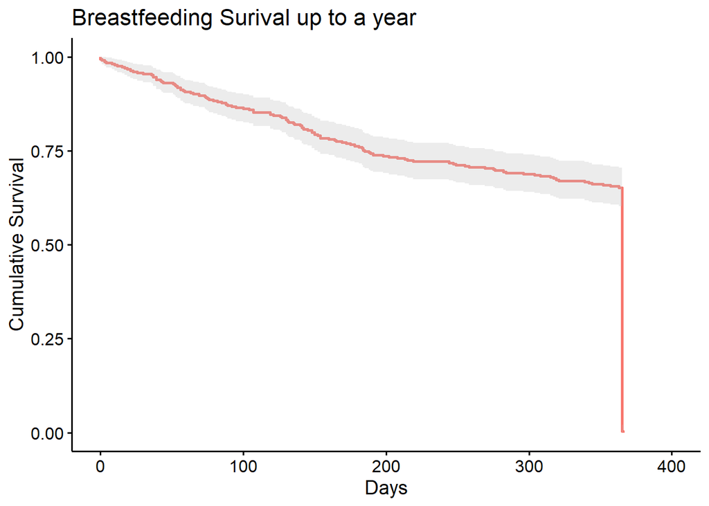

```r
ggsurvplot(surv, conf.int=TRUE, ylim=c(0, 1),
           title='Breastfeeding Surival up to a year',
           ylab='Cumulative Survival', xlab='Days',
           legend='none')
```

```r
#Probability of breasting up to a year after delivery
summary(survfit(Surv(duration_bf, censor) ~ 1, data = wales_data_followup), times = 365)
```

```
## Call: survfit(formula = Surv(duration_bf, censor) ~ 1, data = wales_data_followup)
##
## 419 observations deleted due to missingness
##  time n.risk n.event survival std.err lower 95% CI upper 95% CI
##   365    218     333  0.00299 0.00299     0.000423       0.0212
```

### Merge followup data to the main dataset

```r
#select only needed columns
wales_data_followup <- wales_data_followup %>% select(STUDY_ID, initiate_bf, duration_bf, censor)

#change column name to match that of main dataset
col_names = c('Patient_ID', 'initiate_bf', 'duration_bf', 'censor')
colnames(wales_data_followup) <- col_names

#merge datasets
wales_data_2022 <- wales_data_2022 %>% full_join(wales_data_followup, by ='Patient_ID')
```

### Cox regression model

#### Length of work hours and breastfeeding duration

```r
surv1 <- survfit(Surv(duration_bf, censor) ~ Length_work_hrs, data = wales_data_2022)

print(surv1)
```

```
## Call: survfit(formula = Surv(duration_bf, censor) ~ Length_work_hrs,
##     data = wales_data_2022)
##
##    543 observations deleted due to missingness
##                             n events median 0.95LCL 0.95UCL
## Length_work_hrs=Full time 153    153    321     215      NA
## Length_work_hrs=Part-time  56     56    365      NA      NA
## Length_work_hrs=Other       3      3    365      NA      NA
```

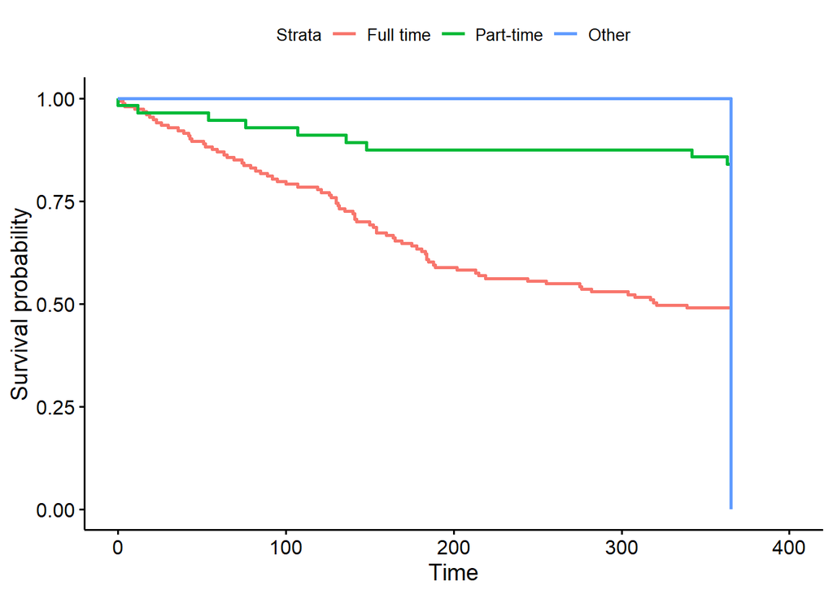

```r
ggsurvplot(surv1, data=wales_data_2022,
           legend.labs=c('Full time','Part-time', 'Other'))
```

```r
#Cox regression
coxph(Surv(duration_bf, censor) ~ Length_work_hrs, data = wales_data_2022) %>%
  gtsummary::tbl_regression(exp = TRUE)
```

| **Characteristic** | **HR**<sup>1</sup> | **95% CI**<sup>1</sup> | **p-value** |
| --- | --- | --- | --- |
| Length_work_hrs |  |  |  |
| Full time | — | — |  |
| Part-time | 0.66 | 0.49, 0.90 | 0.008 |
| Other | 0.57 | 0.18, 1.79 | 0.3 |

<sup>1</sup> HR = Hazard Ratio, CI = Confidence Interval

### Marital status and breastfeeding duration

```r
#Cox regression
coxph(Surv(duration_bf, censor) ~ Marital_status, data = wales_data_2022) %>%
  gtsummary::tbl_regression(exp = TRUE)
```

| **Characteristic** | **HR**<sup>1</sup> | **95% CI**<sup>1</sup> | **p-value** |
| --- | --- | --- | --- |
| Marital_status |  |  |  |
| Dating | — | — |  |
| Engaged | 1.65 | 0.46, 5.93 | 0.4 |
| Living with partner/civil partnership | 0.83 | 0.45, 1.53 | 0.5 |
| Married | 0.87 | 0.47, 1.60 | 0.6 |
| Other | 0.61 | 0.08, 4.74 | 0.6 |
| Separated | 0.61 | 0.08, 4.74 | 0.6 |
| Single | 1.03 | 0.44, 2.42 | >0.9 |

<sup>1</sup> HR = Hazard Ratio, CI = Confidence Interval

### Let’s draw the demographic table to summarize the characteristics

```r
#re-ordering the levels
wales_data_2022$Language <-
  factor(wales_data_2022$Language, levels=c('English', 'Welsh', 'Other'))

wales_data_2022$Ethnicity <-
  factor(wales_data_2022$Ethnicity, levels=c('White', 'Asian', 'Mixed', 'Other'))

wales_data_2022$Nationality <-
  factor(wales_data_2022$Nationality, levels=c('British','Welsh', 'European', 'Other'))

wales_data_2022$Marital_status <-
  factor(wales_data_2022$Marital_status, levels=c('Married','Living with partner/civil partnership', 'Single', 'Dating', 'Engaged', '(Other)'))

wales_data_2022$Gender <-
  factor(wales_data_2022$Gender, levels=c('Heterosexual or straight','Bisexual', 'Homosexual or lesbian', 'Other'))

wales_data_2022$mode_of_feeding_intent <-
  factor(wales_data_2022$mode_of_feeding_intent, levels=c('Breast milk only', 'Breast and bottle', 'Bottle milk only', 'Don\'t know yet', 'Other'))

wales_data_2022$Occupation <-
  factor(wales_data_2022$Occupation, levels=c('Civil Service', 'Healthcare', 'Blue Collar worker', 'Home maker', 'Self employed', 'Unemployed'))


wales_data_2022$Education_level <-
  factor(wales_data_2022$Education_level, levels=c('Secondary Education', 'University degree', 'University higher degree', 'Vocational qualifications', 'Other'))

wales_data_2022$Employment_status <-
  factor(wales_data_2022$Employment_status, levels=c('Working', 'Not working'))

wales_data_2022$Household_income <-
  factor(wales_data_2022$Household_income, levels=c('< £10,000', '£10,000 - £50,000', '> £50,000', 'Other'))

wales_data_2022$Other_children <-
  factor(wales_data_2022$Other_children, levels=c('No', 'Yes', 'Prefer not to say'))

wales_data_2022$BMI_range <-
  factor(wales_data_2022$BMI_range, levels=c('Underweight', 'Healthy weight', 'Overweight', 'Obese'))

wales_data_2022$effect_of_covid_on_birth_type <- factor(wales_data_2022$effect_of_covid_on_birth_type, levels=c('No', 'Yes', 'Don\'t know yet'))

wales_data_2022$Test_taken <- factor(wales_data_2022$Test_taken, levels=c('No', 'Yes (Negative)', 'Yes (Positive)'))

wales_data_2022$Other_children <-
  factor(wales_data_2022$Other_children, levels=c('No', 'Yes', 'Prefer not to say'))

wales_data_2022$Walking_pace <-
  factor(wales_data_2022$Walking_pace, levels=c('Slow pace', 'Steady average pace', 'Brisk pace', 'Fast pace'))

wales_data_2022$Stress_in_preg <-
  factor(wales_data_2022$Stress_in_preg, levels=c('No', 'Yes', 'Prefer not to say'))

wales_data_2022$Treatment_taken <-
  factor(wales_data_2022$Treatment_taken, levels=c('No', 'Yes'))

#Adjust label names for variables
table_1 <- wales_data_2022 %>%
    select(-Patient_ID, -Start_date, -EDD, -Age_of_children, -No_of_children, -No_in_household, -BMI)

table1::label(table_1$Marital_status) <- "Marital status"

table1::label(table_1$mode_of_feeding_intent) <- "Mode of feeding intent"

table1::label(table_1$Other_children) <- "Woman has other children"

table1::label(table_1$Employment_status) <- "Employment status"

table1::label(table_1$Education_level) <- "Educational level"

table1::label(table_1$Household_income) <- "Household income"

table1::label(table_1$household) <- "Number of Household members (excluding mother)"

table1::label(table_1$BMI_range) <- "Weight before pregnancy"

table1::label(table_1$children) <- "Number of Children"

table1::label(table_1$Covid_symptoms) <- "Had COVID-19 Symptoms"

table1::label(table_1$Kind_of_symptoms) <- "Number of symptoms"

table1::label(table_1$Treatment_taken) <- "Treatment taken"

table1::label(table_1$Test_taken) <- "Test taken"

table1::label(table_1$effect_of_covid_on_birth_type) <- "If COVID-19 will affect planned birth type"

table1::label(table_1$contact_no_touch) <- "Number of people outside houshold mother met but no close contact "

table1::label(table_1$contact_touch) <- "Number of people outside houshold mother had close contact with"

table1::label(table_1$Type_of_maternity_care_received) <- "Type of Maternity care received during pregnancy"

table1::label(table_1$satisfaction_with_healthcare_support_at_preg) <- "Level of satisfaction with Healthcare support during pregnancy"

table1::label(table_1$Length_work_hrs) <- "Work Type"

table1::label(table_1$Physical_activity_at_work) <- "Physical activity at work"

table1::label(table_1$Walking_pace) <- "Walking pace"

table1::label(table_1$no_of_symptoms) <- "Number of symptoms experienced"

table1::label(table_1$PA_scale) <- "Level of Physical activity (including sports, leisure and house chores"

table1::label(table_1$Depression_scale) <- "Level of Depression"

table1::label(table_1$Anxiety_scale) <- "Level of Anxiety"

table1::label(table_1$scale_of_stress_at_this_time) <- "Scale of stress"

table1::label(table_1$Low_mood_while_preg) <- "Low mood experienced during pregnancy"

table1::label(table_1$Stress_in_preg) <- "Stress experienced during pregnancy"

table1::label(table_1$Relationship_issues) <- "Relationship issues experienced during pregnancy"

table1::label(table_1$Legal_finance_issues) <- "Experience with legal or financial issues"

table1::label(table_1$Victim_of_violence_crime_or_loved_one_is_victim) <- "Experience of violence or crime to mother or loved one"

table1::label(table_1$illness_of_loved_one) <- "Illness of loved one"

table1::label(table_1$death_of_loved_one) <- "Death of loved one"

table1::label(table_1$is_event_covid_related) <- "If Illness or Death of loved one is COVID-19 related"

table1::label(table_1$emotional_finance_support_at_this_time) <- "If emotional or Financial support was received at this time"

table1::label(table_1$initiate_bf) <- "Initiated Breastfeeding"


table1::table1(~Language + Ethnicity + Nationality + Marital_status + Gender + Education_level + BMI_range + mode_of_feeding_intent + initiate_bf + Other_children + children + Occupation + Employment_status + Length_work_hrs + Household_income + household + Covid_symptoms + no_of_symptoms + Treatment_taken + Test_taken + effect_of_covid_on_birth_type + contact_no_touch + contact_touch + Type_of_maternity_care_received + satisfaction_with_healthcare_support_at_preg + Physical_activity_at_work + PA_scale + Walking_pace + Low_mood_while_preg + Depression_scale + Anxiety_scale + Stress_in_preg + Relationship_issues + Legal_finance_issues + Victim_of_violence_crime_or_loved_one_is_victim + illness_of_loved_one + death_of_loved_one + is_event_covid_related + emotional_finance_support_at_this_time + scale_of_stress_at_this_time + Smoking + Alcohol, data = table_1, topclass="Rtable1-grid")
```

|  | Overall (N=755) |
| --- | --- |
| Language |  |
| English | 701 (92.8%) |
| Welsh | 37 (4.9%) |
| Other | 9 (1.2%) |
| Missing | 8 (1.1%) |
| Ethnicity |  |
| White | 721 (95.5%) |
| Asian | 8 (1.1%) |
| Mixed | 16 (2.1%) |
| Other | 2 (0.3%) |
| Missing | 8 (1.1%) |
| Nationality |  |
| British | 667 (88.3%) |
| Welsh | 48 (6.4%) |
| European | 18 (2.4%) |
| Other | 15 (2.0%) |
| Missing | 7 (0.9%) |
| Marital status |  |
| Married | 344 (45.6%) |
| Living with partner/civil partnership | 319 (42.3%) |
| Single | 36 (4.8%) |
| Dating | 34 (4.5%) |
| Engaged | 5 (0.7%) |
| (Other) | 0 (0%) |
| Missing | 17 (2.3%) |
| Gender |  |
| Heterosexual or straight | 522 (69.1%) |
| Bisexual | 29 (3.8%) |
| Homosexual or lesbian | 6 (0.8%) |
| Other | 4 (0.5%) |

[output cut: 200 more lines]

### Create Logistic Regression table to summarize the associations

```r
### Create binary variable for intent to breastfeed
wales_data_2022$Intent_BF <- recode(wales_data_2022$mode_of_feeding_intent, 'Breast milk only' = 1, 'Breast and bottle' = 1, 'Bottle milk only' = 0, 'Other' = 0, 'Don\'t know yet' = 0)

wales_data_2022$Intent_BF <- as.factor(wales_data_2022$Intent_BF)

#Select variables for regression model
model <- wales_data_2022 %>% select(Marital_status, Education_level, BMI_range, Low_mood_while_preg, Stress_in_preg, Relationship_issues, Legal_finance_issues, Victim_of_violence_crime_or_loved_one_is_victim, illness_of_loved_one, death_of_loved_one, is_event_covid_related, emotional_finance_support_at_this_time, Intent_BF, children, Smoking, Alcohol)


mod1 <- glm(Intent_BF ~ Marital_status + Education_level + BMI_range + Low_mood_while_preg + Stress_in_preg,
            data = model, family = binomial)
t1 <- tbl_regression(mod1, exponentiate = TRUE)
t1
```

| **Characteristic** | **OR**<sup>1</sup> | **95% CI**<sup>1</sup> | **p-value** |
| --- | --- | --- | --- |
| Marital_status |  |  |  |
| Married | — | — |  |
| Living with partner/civil partnership | 1.08 | 0.64, 1.85 | 0.8 |
| Single | 0.48 | 0.17, 1.43 | 0.2 |
| Dating | 0.90 | 0.31, 2.98 | 0.8 |
| Engaged | 2,829,521 | 0.00, NA | >0.9 |
| Education_level |  |  |  |
| Secondary Education | — | — |  |
| University degree | 1.99 | 1.10, 3.59 | 0.023 |
| University higher degree | 2.87 | 1.35, 6.37 | 0.007 |
| Vocational qualifications | 1.20 | 0.52, 2.92 | 0.7 |
| Other | 9,633,815 | 0.00, NA | >0.9 |
| BMI_range |  |  |  |
| Underweight | — | — |  |
| Healthy weight | 0.49 | 0.03, 2.90 | 0.5 |
| Overweight | 0.24 | 0.01, 1.36 | 0.2 |
| Obese | 0.17 | 0.01, 0.99 | 0.11 |
| Low_mood_while_preg |  |  |  |
| No | — | — |  |
| Yes | 1.42 | 0.81, 2.48 | 0.2 |
| Stress_in_preg |  |  |  |
| No | — | — |  |
| Yes | 0.83 | 0.48, 1.45 | 0.5 |
| Prefer not to say | 0.90 | 0.19, 6.52 | >0.9 |

<sup>1</sup> OR = Odds Ratio, CI = Confidence Interval

```r
mod2 <- glm(Intent_BF ~ Relationship_issues + Legal_finance_issues + Victim_of_violence_crime_or_loved_one_is_victim + illness_of_loved_one + death_of_loved_one, data = model, family = binomial)
t2 <- tbl_regression(mod2, exponentiate = TRUE)
t2
```

| **Characteristic** | **OR**<sup>1</sup> | **95% CI**<sup>1</sup> | **p-value** |
| --- | --- | --- | --- |
| Relationship_issues |  |  |  |
| No | — | — |  |
| Yes | 1.53 | 0.68, 3.82 | 0.3 |
| Legal_finance_issues |  |  |  |
| No | — | — |  |
| Yes | 0.49 | 0.22, 1.18 | 0.10 |
| Victim_of_violence_crime_or_loved_one_is_victim |  |  |  |
| No | — | — |  |
| Yes | 2.69 | 0.50, 50.0 | 0.4 |
| illness_of_loved_one |  |  |  |
| No | — | — |  |
| Yes | 1.07 | 0.47, 2.67 | 0.9 |
| death_of_loved_one |  |  |  |
| No | — | — |  |
| Yes | 0.93 | 0.35, 2.84 | 0.9 |

<sup>1</sup> OR = Odds Ratio, CI = Confidence Interval

```r
mod3 <- glm(Intent_BF ~ is_event_covid_related + emotional_finance_support_at_this_time + children + Smoking + Alcohol,
            data = model, family = binomial)
t3 <- tbl_regression(mod3, exponentiate = TRUE)
t3
```

| **Characteristic** | **OR**<sup>1</sup> | **95% CI**<sup>1</sup> | **p-value** |
| --- | --- | --- | --- |
| is_event_covid_related |  |  |  |
| No | — | — |  |
| Yes | 4.20 | 1.08, 28.0 | 0.070 |
| emotional_finance_support_at_this_time |  |  |  |
| No | — | — |  |
| Yes | 0.59 | 0.17, 1.80 | 0.4 |
| children |  |  |  |
| 0 | — | — |  |
| 1 - 2 | 3.58 | 0.13, 98.8 | 0.4 |
| 3 and above | 4.93 | 0.16, 155 | 0.3 |
| Smoking |  |  |  |
| No | — | — |  |
| Yes | 0.34 | 0.10, 1.14 | 0.079 |
| Alcohol |  |  |  |
| No | — | — |  |
| Yes | 7,239,206 | 0.00, NA | >0.9 |

<sup>1</sup> OR = Odds Ratio, CI = Confidence Interval

### Decision tree

```r
dt <- wales_data_2022 %>% select(Patient_ID, Marital_status, Education_level, BMI_range, Other_children, Household_income, Type_of_maternity_care_received, satisfaction_with_healthcare_support_at_preg, Low_mood_while_preg, Stress_in_preg, Intent_BF, Smoking, Alcohol)
```

### Shuffle the data

```r
shuffle_index <- sample(1:nrow(dt))
dt <- dt[shuffle_index, ]
head(dt)
```

```
##     Patient_ID                        Marital_status          Education_level
## 2            2                               Married        University degree
## 413        412                               Married University higher degree
## 636        636                               Married University higher degree
## 330        331 Living with partner/civil partnership University higher degree
## 67          68 Living with partner/civil partnership        University degree
## 692        695 Living with partner/civil partnership        University degree
##          BMI_range Other_children  Household_income
## 2   Healthy weight            Yes £10,000 - £50,000
## 413 Healthy weight             No £10,000 - £50,000
## 636 Healthy weight            Yes         > £50,000
## 330 Healthy weight             No £10,000 - £50,000
## 67           Obese             No £10,000 - £50,000
## 692     Overweight             No £10,000 - £50,000
##     Type_of_maternity_care_received
```

[output cut: 20 more lines]

```r
dt <- dt %>%
mutate(Intent_BF = factor(Intent_BF, levels = c(0, 1), labels = c('No Intent', 'Has Intent')))
```

### Remove all NAs

```r
dt <- dt %>% select(-Patient_ID) %>% na.omit()
```

### Split data into Train (80%) and Test sets (20%)

```r
bound <- nrow(dt)*0.80 #Split 80% of the data to be trained
dt_Train <- dt[1:bound,] #Get training set
dt_Test <- dt[(bound+1):nrow(dt),] #Get testing set
```

### Let’s train the data and draw decision tree

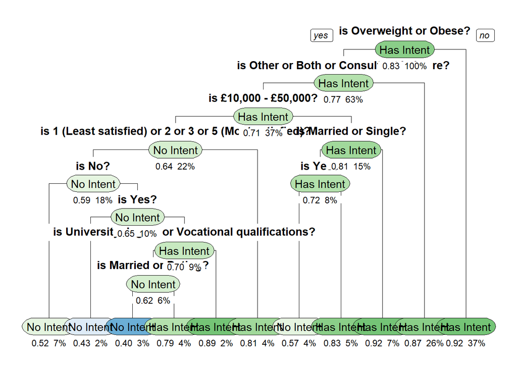

```r
fit <- rpart(Intent_BF ~., data = dt_Train, method = 'class',
             parms=list(loss=matrix(c(0,1,2,0),2)))

rpart.plot(fit, type = 1, extra = 106, under = TRUE, tweak = 1.5, gap = 0, clip.right.labs = FALSE, clip.facs = TRUE, split.prefix = "is ", split.suffix = "?", eq = " ", facsep = " or ")
```

```r
#save the decision tree as png. file
png("decision-tree.png", width=1000, height=800, antialias="cleartype")
rpart.plot(fit, main="Classification Tree")
dev.off()
```

### Let’s make prediction using test data

```r
prediction <- predict(fit, dt_Test, type = 'class')

confusionMatrix(table(Observed = dt_Test$Intent_BF, Predicted = prediction))
```

```
## Confusion Matrix and Statistics
##
##             Predicted
## Observed     No Intent Has Intent
##   No Intent          3         15
##   Has Intent         7         72
##
##                Accuracy : 0.7732
##                  95% CI : (0.677, 0.8521)
##     No Information Rate : 0.8969
##     P-Value [Acc > NIR] : 0.9999
##
##                   Kappa : 0.0942
##
##  Mcnemar's Test P-Value : 0.1356
##
##             Sensitivity : 0.30000
##             Specificity : 0.82759
##          Pos Pred Value : 0.16667
##          Neg Pred Value : 0.91139
##              Prevalence : 0.10309
##          Detection Rate : 0.03093
##    Detection Prevalence : 0.18557
##       Balanced Accuracy : 0.56379
##
##        'Positive' Class : No Intent
##
```

#Here we can see the results of our confusion matrix but the positive class is not right. Let’s solve this.

### See levels of Breastfeeding intent

```r
levels(dt_Train$Intent_BF)
```

```
## [1] "No Intent"  "Has Intent"
```

#No intent comes first, that why it was selected as the positive class by the confusion matrix, so we will relevel the factor

```r
dt_Train$Intent_BF <- fct_relevel(dt_Train$Intent_BF, 'Has Intent', 'No Intent')

dt_Test$Intent_BF <- fct_relevel(dt_Test$Intent_BF, 'Has Intent', 'No Intent')

levels(dt_Test$Intent_BF)
```

```
## [1] "Has Intent" "No Intent"
```

### Now let’s run the model again

```r
fit <- rpart(Intent_BF ~., data = dt_Train, method = 'class')

prediction <- predict(fit, dt_Test, type = 'class')

confusionMatrix(table(Observed = dt_Test$Intent_BF, Predicted = prediction))
```

```
## Confusion Matrix and Statistics
##
##             Predicted
## Observed     Has Intent No Intent
##   Has Intent         79         0
##   No Intent          18         0
##
##                Accuracy : 0.8144
##                  95% CI : (0.7227, 0.8862)
##     No Information Rate : 1
##     P-Value [Acc > NIR] : 1
##
##                   Kappa : 0
##
##  Mcnemar's Test P-Value : 6.151e-05
##
##             Sensitivity : 0.8144
##             Specificity :     NA
##          Pos Pred Value :     NA
##          Neg Pred Value :     NA
##              Prevalence : 1.0000
##          Detection Rate : 0.8144
##    Detection Prevalence : 0.8144
##       Balanced Accuracy :     NA
##
##        'Positive' Class : Has Intent
##
```